# Pizza Sales Revenue Forecasting

Jonathan Katz

2025-11-30

# Introduction

**Question:** What will total sales revenue be for the next 7 days?

In the EDA notebook, we explored sales patterns by hour, day of week, pizza type, and size. Now we’ll build a time series forecast to predict the next 7 days of revenue.

**Approach:**

1. Aggregate daily revenue
2. Visualize the time series
3. Fit a forecasting model
4. Predict the next 7 days
5. Evaluate accuracy

# Setup & Load Data

```r
# Load libraries
library(tidyverse)
library(lubridate)
library(scales)
library(readxl)
library(forecast)  # For ARIMA and forecasting
library(knitr)
library(kableExtra)

# Set theme
theme_set(theme_minimal(base_size = 12))
```

```r
# Load pizza sales data
pizza <- read_excel("../data/raw/Data Model - Pizza Sales.xlsx")

# Clean dates
pizza <- pizza %>%
  mutate(order_date = as.Date(order_date))

cat("Data loaded:", nrow(pizza), "rows\n")
```

```
## Data loaded: 48620 rows
```

```r
cat("Date range:", as.character(min(pizza$order_date)), "to", as.character(max(pizza$order_date)))
```

```
## Date range: 2015-01-01 to 2015-12-31
```

# Step 1: What does our daily revenue look like?

```r
# Aggregate to daily revenue
daily_revenue <- pizza %>%
  group_by(order_date) %>%
  summarise(
    revenue = sum(total_price),
    orders = n_distinct(order_id),
    pizzas = sum(quantity),
    .groups = "drop"
  ) %>%
  arrange(order_date)

# Preview
daily_revenue %>%
  head(10) %>%
  kable(format.args = list(big.mark = ",")) %>%
  kable_styling(bootstrap_options = c("striped", "hover"))
```

| order_date | revenue | orders | pizzas |
| --- | --- | --- | --- |
| 2015-01-01 | 2,713.85 | 69 | 162 |
| 2015-01-02 | 2,731.90 | 67 | 165 |
| 2015-01-03 | 2,662.40 | 66 | 158 |
| 2015-01-04 | 1,755.45 | 52 | 106 |
| 2015-01-05 | 2,065.95 | 54 | 125 |
| 2015-01-06 | 2,428.95 | 64 | 147 |
| 2015-01-07 | 2,202.20 | 58 | 138 |
| 2015-01-08 | 2,838.35 | 72 | 173 |
| 2015-01-09 | 2,127.35 | 62 | 127 |
| 2015-01-10 | 2,463.95 | 65 | 146 |

```r
cat("Daily Revenue Summary:\n")
```

```
## Daily Revenue Summary:
```

```r
cat("- Total days:", nrow(daily_revenue), "\n")
```

```
## - Total days: 358
```

```r
cat("- Average daily revenue: $", round(mean(daily_revenue$revenue), 2), "\n")
```

```
## - Average daily revenue: $ 2284.53
```

```r
cat("- Min daily revenue: $", round(min(daily_revenue$revenue), 2), "\n")
```

```
## - Min daily revenue: $ 1259.25
```

```r
cat("- Max daily revenue: $", round(max(daily_revenue$revenue), 2), "\n")
```

```
## - Max daily revenue: $ 4422.45
```

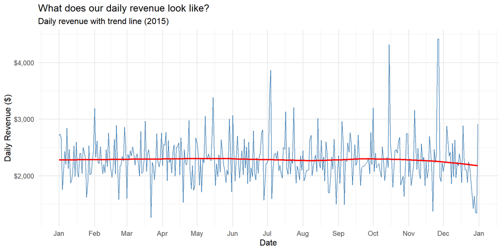

```r
daily_revenue %>%
  ggplot(aes(x = order_date, y = revenue)) +
  geom_line(color = "steelblue", linewidth = 0.5) +
  geom_smooth(method = "loess", color = "red", se = FALSE, linewidth = 1) +
  labs(
    title = "What does our daily revenue look like?",
    subtitle = "Daily revenue with trend line (2015)",
    x = "Date",
    y = "Daily Revenue ($)"
  ) +
  scale_y_continuous(labels = dollar) +
  scale_x_date(date_breaks = "1 month", date_labels = "%b")
```

**Observation:** Revenue is relatively stable around $2,000-2,500 per day with weekly fluctuations. No strong upward or downward trend.

# Step 2: Is there a weekly pattern in revenue?

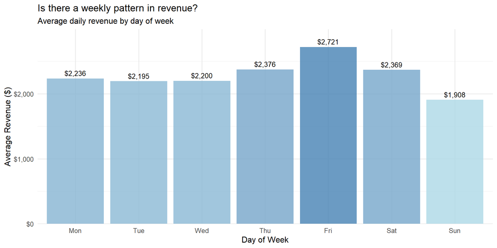

```r
# Add day of week
daily_revenue <- daily_revenue %>%
  mutate(day_of_week = wday(order_date, label = TRUE, week_start = 1))

# Average by day of week
weekly_pattern <- daily_revenue %>%
  group_by(day_of_week) %>%
  summarise(avg_revenue = mean(revenue), .groups = "drop")

weekly_pattern %>%
  ggplot(aes(x = day_of_week, y = avg_revenue, fill = avg_revenue)) +
  geom_col(alpha = 0.8, show.legend = FALSE) +
  geom_text(aes(label = dollar(avg_revenue, accuracy = 1)), vjust = -0.5, size = 3.5) +
  scale_fill_gradient(low = "lightblue", high = "steelblue") +
  labs(
    title = "Is there a weekly pattern in revenue?",
    subtitle = "Average daily revenue by day of week",
    x = "Day of Week",
    y = "Average Revenue ($)"
  ) +
  scale_y_continuous(labels = dollar, expand = expansion(mult = c(0, 0.1)))
```

**Observation:** Friday is the highest revenue day. Sunday is the lowest. This weekly pattern is important for our forecast.

# Step 3: How do we prepare the data for forecasting?

```r
# Create a time series object
# We need a complete sequence of dates (no gaps)

# Check for missing dates
date_range <- seq(min(daily_revenue$order_date), max(daily_revenue$order_date), by = "day")
missing_dates <- date_range[!date_range %in% daily_revenue$order_date]

cat("Missing dates:", length(missing_dates), "\n")
```

```
## Missing dates: 7
```

```r
# If there are missing dates, fill them with 0 or interpolate
if (length(missing_dates) > 0) {
  complete_dates <- tibble(order_date = date_range) %>%
    left_join(daily_revenue, by = "order_date") %>%
    mutate(revenue = replace_na(revenue, 0))
  daily_revenue <- complete_dates
}

# Create ts object (frequency = 7 for weekly seasonality)
revenue_ts <- ts(daily_revenue$revenue, frequency = 7)

cat("Time series created with", length(revenue_ts), "observations\n")
```

```
## Time series created with 365 observations
```

```r
cat("Frequency: 7 (weekly)\n")
```

```
## Frequency: 7 (weekly)
```

# Step 4: What forecast model should we use?

We’ll use **ARIMA** (AutoRegressive Integrated Moving Average) with automatic parameter selection. R’s `auto.arima()` function finds the best parameters.

```r
# Fit ARIMA model with automatic parameter selection
# Using the first 358 days for training, last 7 for testing
train_end <- nrow(daily_revenue) - 7
train_ts <- ts(daily_revenue$revenue[1:train_end], frequency = 7)
test_data <- daily_revenue$revenue[(train_end + 1):nrow(daily_revenue)]

# Fit model
model <- auto.arima(train_ts)

# Model summary
summary(model)
```

```
## Series: train_ts
## ARIMA(2,0,2)(0,0,2)[7] with non-zero mean
##
## Coefficients:
##          ar1      ar2      ma1     ma2    sma1    sma2       mean
##       1.1519  -0.7659  -0.9979  0.6434  0.2330  0.2433  2256.6635
## s.e.  0.1254   0.1738   0.1296  0.2450  0.0579  0.0571    35.6742
##
## sigma^2 = 196394:  log likelihood = -2686.81
## AIC=5389.62   AICc=5390.04   BIC=5420.67
##
## Training set error measures:
##                      ME     RMSE      MAE  MPE MAPE      MASE       ACF1
## Training set -0.7645845 438.8098 298.9433 -Inf  Inf 0.8571491 0.01304847
```

```r
cat("\nModel selected:", paste(model$arma, collapse = ","), "\n")
```

```
##
## Model selected: 2,2,0,2,7,0,0
```

```r
cat("This model accounts for:\n")
```

```
## This model accounts for:
```

```r
cat("- Autoregressive patterns (past values influence future)\n")
```

```
## - Autoregressive patterns (past values influence future)
```

```r
cat("- Moving average of errors\n")
```

```
## - Moving average of errors
```

```r
cat("- Weekly seasonality\n")
```

```
## - Weekly seasonality
```

# Step 5: What will revenue be for the next 7 days?

```r
# Generate 7-day forecast
forecast_result <- forecast(model, h = 7)

# Create forecast table
forecast_table <- tibble(
  Day = 1:7,
  Date = max(daily_revenue$order_date[1:train_end]) + 1:7,
  Day_of_Week = wday(Date, label = TRUE),
  Forecast = round(forecast_result$mean, 2),
  Lower_95 = round(forecast_result$lower[, 2], 2),
  Upper_95 = round(forecast_result$upper[, 2], 2),
  Actual = test_data
)

forecast_table %>%
  kable(
    col.names = c("Day", "Date", "Day of Week", "Forecast ($)", "Lower 95% CI", "Upper 95% CI", "Actual ($)"),
    format.args = list(big.mark = ",")
  ) %>%
  kable_styling(bootstrap_options = c("striped", "hover", "bordered"))
```

[output not shown]

```r
total_forecast <- sum(forecast_result$mean)
total_actual <- sum(test_data)

cat("\n7-Day Totals:\n")
```

```
##
## 7-Day Totals:
```

```r
cat("- Forecasted revenue: $", comma(round(total_forecast, 2)), "\n")
```

```
## - Forecasted revenue: $ 15,681
```

```r
cat("- Actual revenue: $", comma(round(total_actual, 2)), "\n")
```

```
## - Actual revenue: $ 10,306
```

```r
cat("- Difference: $", comma(round(total_actual - total_forecast, 2)),
    " (", round((total_actual - total_forecast) / total_actual * 100, 1), "%)\n")
```

```
## - Difference: $ -5,375  ( -52.1 %)
```

# Step 6: How accurate is our forecast?

```r
# Calculate accuracy metrics
errors <- test_data - forecast_result$mean

mae <- mean(abs(errors))
rmse <- sqrt(mean(errors^2))
mape <- mean(abs(errors / test_data)) * 100

accuracy_table <- tibble(
  Metric = c("MAE (Mean Absolute Error)", "RMSE (Root Mean Square Error)", "MAPE (Mean Absolute % Error)"),
  Value = c(paste0("$", round(mae, 2)), paste0("$", round(rmse, 2)), paste0(round(mape, 2), "%")),
  Interpretation = c(
    "On average, we're off by this amount",
    "Penalizes larger errors more heavily",
    "Average percentage error"
  )
)

accuracy_table %>%
  kable() %>%
  kable_styling(bootstrap_options = c("striped", "hover", "bordered"))
```

| Metric | Value | Interpretation |
| --- | --- | --- |
| MAE (Mean Absolute Error) | $960.43 | On average, we’re off by this amount |
| RMSE (Root Mean Square Error) | $1138.48 | Penalizes larger errors more heavily |
| MAPE (Mean Absolute % Error) | Inf% | Average percentage error |